# Simple Linear Regression

Previously, we provided a high level overview of regression analysis and two core foundational regression models, linear and logistic regression. In this section of the course we’ll go over how to set up, build, evaluate, and interpret our first regression model. We’ll also review model assumptions, construction, evaluation, and interpretation as we’ve previously defined.

There are a lot of new concepts. So if you ever need to get reorganized, remember the pace framework, plan, analyze, construct, and execute.

Each part of pace aligns with a part of the process of regression analysis. Sometimes we have to repeat some steps, but these are the phases to keep in mind. And we’ll go through the process concretely together using examples to help guide you.

To recap, **linear regression is a technique that estimates the linear relationship between a continuous dependent variable and one or more independent variables.**

As we go through simple linear regression together, you’ll combine many of your prior skill sets, including Python programming, exploratory data analysis or EDA, and statistics. These tools will allow you to construct a simple linear regression model that can help you influence strategy and decision making in any company or organization.

The key terms, activities, and learning resources that we explore together in these videos will also be important in the rest of this course, which will refer back to our discussions of simple linear regression. Together, we’ll go through all the stages of pace while learning regression modeling.

We’ll first review the linear regression equation and then learn about estimating parameters using *ordinary least squares*. Then we’ll define each of the four key assumptions of simple linear regression.

As for the analyzed stage, we’ll use Python and EDA to verify if our data meets these assumptions. In the construct stage, we’ll build your first regression model in Python together. You’ll also have opportunities to practice both Python and EDA on your own as well.

We’ll also learn several evaluation metrics and a technique to help you quantify how good your model is. Lastly, aligned with the execute stage, we’ll use our metrics to practice interpreting our results for stakeholders and non technical audiences. I’m so excited to get started on simple linear regression modeling. So let’s begin.

# 1 Ordinary least squares estimation

In prior videos, we’ve mentioned simple linear regression, which is a regression technique that estimates the linear relationship between one independent variable $x$, and one continuous dependent variable $y$. Recall that the linear and linear regression indicates what the data looks like when plotted on an $x$-$y$ coordinate plane, a line.

In simple linear regression, we’re only interested in two variables, one $x$ and one $y$ variable. The equation for a regression line is
$$\text {y= intercept + slope * x}$$

$$y = \beta_0 + \beta_1 X$$

Since we’ll have a number of data points for any given problem, there are many different lines we could draw that might fit the data. However, we’re looking for the best fit line. The line that fits the data best by minimizing a **loss function**, or error.

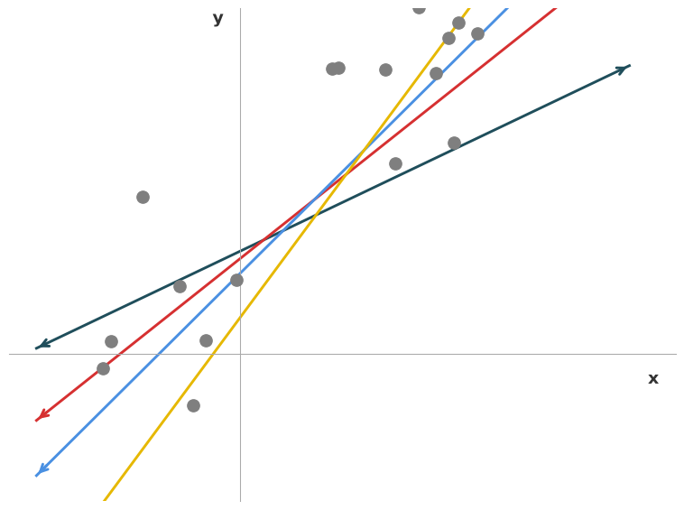

```python
import numpy as np
import matplotlib.pyplot as plt

# Set random seed for consistent data generation
np.random.seed(10)

# 1. Generate scatter plot points with a positive linear trend
n_points = 18
x = np.random.uniform(-1.5, 3.5, n_points)
y = 1.2 * x + 1.5 + np.random.normal(0, 0.8, n_points)

# 2. Set up figure and clean axis styling
fig, ax = plt.subplots(figsize=(8, 6), facecolor='white')

# Remove top and right spines
ax.spines['top'].set_visible(False)
ax.spines['right'].set_visible(False)

# Position left/bottom spines through the origin (0,0) area to match the image
ax.spines['left'].set_position(('data', 0))
ax.spines['bottom'].set_position(('data', 0))
ax.spines['left'].set_color('#aaaaaa')
ax.spines['bottom'].set_color('#aaaaaa')

# Hide numerical tick marks and labels for a clean visual concept
ax.set_xticks([])
ax.set_yticks([])

# 3. Plot the scatter points (grey dots)
ax.scatter(x, y, color='#7f7f7f', s=100, zorder=3)

# 4. Draw multiple candidate regression lines intersecting near the center
x_line = np.linspace(-2.2, 4.2, 200)

lines_config = [
    # (slope, intercept, color)
    (0.6, 1.4, '#1f4e5b'),   # Dark Teal line (lower slope)
    (1.0, 1.3, '#d63031'),   # Red line (best fit)
    (1.25, 1.1, '#4a90e2'),  # Blue line (slightly steeper)
    (1.7, 0.5, '#e6b800'),   # Yellow line (steep slope)
]

for slope, intercept, color in lines_config:
    y_line = slope * x_line + intercept

    # Plot line
    ax.plot(x_line, y_line, color=color, linewidth=2.2, zorder=2)

    # Add double-ended arrowheads matching the original image
    # End arrow (top-right)
    ax.annotate(
        '', xy=(x_line[-1], y_line[-1]), xytext=(x_line[-5], y_line[-5]),
        arrowprops=dict(arrowstyle='->', color=color, lw=2.2, mutation_scale=15),
        zorder=2
    )
    # Start arrow (bottom-left)
    ax.annotate(
        '', xy=(x_line[0], y_line[0]), xytext=(x_line[4], y_line[4]),
        arrowprops=dict(arrowstyle='->', color=color, lw=2.2, mutation_scale=15),
        zorder=2
    )

# 5. Add Axis Labels ('x' and 'y')
ax.text(4.4, -0.4, 'x', fontsize=14, fontweight='bold', color='#333333')
ax.text(-0.3, 4.5, 'y', fontsize=14, fontweight='bold', color='#333333')

# Adjust layout limits
ax.set_xlim(-2.5, 4.7)
ax.set_ylim(-2.0, 4.7)

plt.tight_layout()
plt.show()
```

In order to find the best fit line, we need to measure error. We can consider error as some difference between the data we have, the observed values, and the predicted values generated by a given model.

The predicted values are the estimated $y$ values for each $x$ calculated by a model. The difference between observed or actual values and the predicted values of the regression line are what’s known as a **residual**.

The equation for residual value is residual equals observed value minus predicted value.
$$\epsilon_i = Y_i - \hat{Y}_i$$
Each data point has one residual.  Epsilon is a Greek letter that resembles the letter E, as in E for error.

We can calculate individual residuals for each data point. An important thing to note is that **the sum of the residuals is always equal to zero for OLS (Ordinary Least Squares) estimators**. For some estimators, the sum of the residuals is not always equal to zero.

For linear regression, we’ll be using a technique called **ordinary least squares** to get our best-fit line.

Ordinary least squares, also known as OLS, is a method that minimizes the sum of squared residuals to estimate parameters in a linear regression model.

Using OLS, we can calculate $\hat{\beta_0}$ and $\hat{\beta_1}$ using properties of the sample data. Recall that the hat symbol means it is an estimate of a parameter. We will never know the exact parameter.

Remember parameters or Betas are characteristics of a population. Since we will only ever have sampled data, our goal is to get a reasonable estimate of the parameter.

Let’s say that we have a certain sample of data and we now want to determine a line that fits the data well. For our first attempt at a best-fit line, the slope is 1 and the intercept is 2.5.

To calculate the sum of squared residuals, first, we calculate the predicted values for each $x$. Next, we can find the residual for every observed value of $x$. On the graph we’ve plotted the residuals. The residuals are the difference between each observed value and what the line predicted.

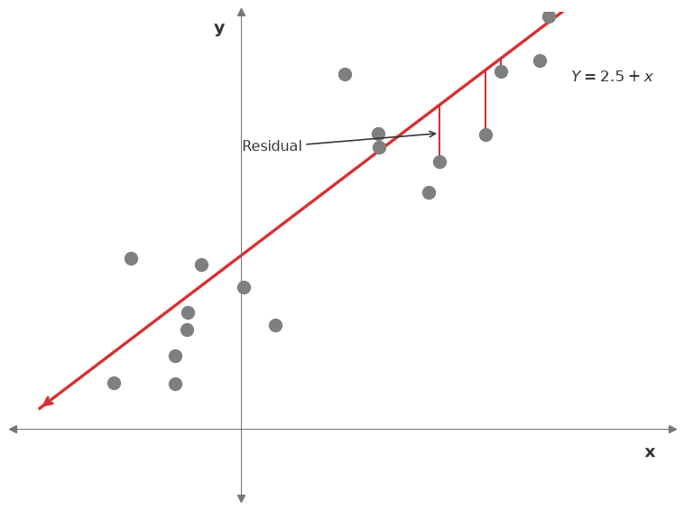

```python
import numpy as np
import matplotlib.pyplot as plt

# Set random seed for consistent data generation
np.random.seed(42)

# 1. Generate scatter plot points following Y = 2.5 + x with some noise
n_points = 18
x = np.random.uniform(-1.5, 3.5, n_points)
y = 2.5 + 1.0 * x + np.random.normal(0, 0.8, n_points)

# Select specific indices to display red vertical residual lines
residual_indices = [2, 7, 12]

# 2. Set up figure and clean axis styling
fig, ax = plt.subplots(figsize=(8, 6), facecolor='white')

# Remove top and right spines
ax.spines['top'].set_visible(False)
ax.spines['right'].set_visible(False)

# Position axes through the origin (0,0)
ax.spines['left'].set_position(('data', 0))
ax.spines['bottom'].set_position(('data', 0))
ax.spines['left'].set_color('#777777')
ax.spines['bottom'].set_color('#777777')

# Hide tick marks and numbers for a clean conceptual look
ax.set_xticks([])
ax.set_yticks([])

# Add double-ended arrowheads to the main x and y axes
ax.plot(1, 0, ">k", transform=ax.get_yaxis_transform(), clip_on=False, color='#777777')
ax.plot(0, 1, "^k", transform=ax.get_xaxis_transform(), clip_on=False, color='#777777')
ax.plot(0, 0, "<k", transform=ax.get_yaxis_transform(), clip_on=False, color='#777777')
ax.plot(0, 0, "vk", transform=ax.get_xaxis_transform(), clip_on=False, color='#777777')

# 3. Draw vertical residual lines (red) from selected points to the regression line
for idx in residual_indices:
    px, py = x[idx], y[idx]
    y_pred = 2.5 + px
    ax.vlines(x=px, ymin=min(py, y_pred), ymax=max(py, y_pred), color='#d63031', linewidth=1.5, zorder=2)

# 4. Plot scatter points (grey circles)
ax.scatter(x, y, color='#7f7f7f', s=110, zorder=3)

# 5. Draw the main red regression line: Y = 2.5 + x
x_line = np.linspace(-2.2, 4.2, 200)
y_line = 2.5 + x_line
ax.plot(x_line, y_line, color='#d63031', linewidth=2.5, zorder=2)

# Add double-ended arrowheads to the red regression line
ax.annotate(
    '', xy=(x_line[-1], y_line[-1]), xytext=(x_line[-5], y_line[-5]),
    arrowprops=dict(arrowstyle='->', color='#d63031', lw=2.5, mutation_scale=15),
    zorder=2
)
ax.annotate(
    '', xy=(x_line[0], y_line[0]), xytext=(x_line[4], y_line[4]),
    arrowprops=dict(arrowstyle='->', color='#d63031', lw=2.5, mutation_scale=15),
    zorder=2
)

# 6. Annotations: Equation label, "Residual" label with arrow, and axis names
# Equation label
ax.text(3.6, 5.0, r'$Y = 2.5 + x$', fontsize=13, fontweight='bold', color='#333333')

# Axis labels
ax.text(4.4, -0.4, 'x', fontsize=14, fontweight='bold', color='#333333')
ax.text(-0.3, 5.7, 'y', fontsize=14, fontweight='bold', color='#333333')

# "Residual" text with arrow pointing to the leftmost highlighted residual line
target_x = x[residual_indices[0]]
target_y_mid = (y[residual_indices[0]] + (2.5 + target_x)) / 2

ax.annotate(
    'Residual',
    xy=(target_x, target_y_mid),
    xytext=(target_x - 1.5, target_y_mid - 0.2),
    arrowprops=dict(arrowstyle='->', color='#333333', lw=1.2),
    fontsize=12,
    color='#333333',
    ha='right',
    va='center'
)

# Set axis boundaries
ax.set_xlim(-2.5, 4.7)
ax.set_ylim(-1.0, 6.0)

plt.tight_layout()
plt.show()
```

But let’s try to get a little bit closer to the points. Let’s try another line. This time, we’ll set the slope equal to 1.25 and the intercept equal to 3.

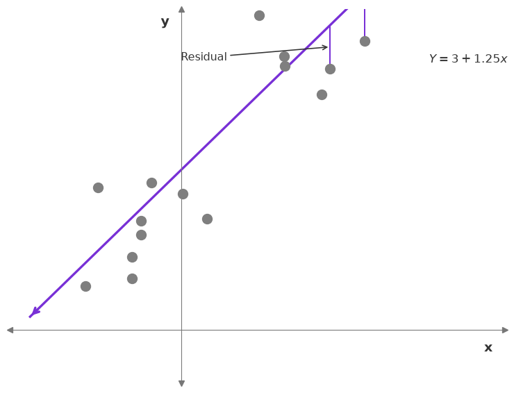

```python
import numpy as np
import matplotlib.pyplot as plt

# Set random seed for consistent data generation
np.random.seed(42)

# 1. Generate scatter plot points following Y = 2.5 + x with some noise
n_points = 18
x = np.random.uniform(-1.5, 3.5, n_points)
y = 3 + 1.25 * x + np.random.normal(0, 0.8, n_points)

# Select specific indices to display red vertical residual lines
residual_indices = [2, 7, 12]

# 2. Set up figure and clean axis styling
fig, ax = plt.subplots(figsize=(8, 6), facecolor='white')

# Remove top and right spines
ax.spines['top'].set_visible(False)
ax.spines['right'].set_visible(False)

# Position axes through the origin (0,0)
ax.spines['left'].set_position(('data', 0))
ax.spines['bottom'].set_position(('data', 0))
ax.spines['left'].set_color('#777777')
ax.spines['bottom'].set_color('#777777')

# Hide tick marks and numbers for a clean conceptual look
ax.set_xticks([])
ax.set_yticks([])

# Add double-ended arrowheads to the main x and y axes
ax.plot(1, 0, ">k", transform=ax.get_yaxis_transform(), clip_on=False, color='#777777')
ax.plot(0, 1, "^k", transform=ax.get_xaxis_transform(), clip_on=False, color='#777777')
ax.plot(0, 0, "<k", transform=ax.get_yaxis_transform(), clip_on=False, color='#777777')
ax.plot(0, 0, "vk", transform=ax.get_xaxis_transform(), clip_on=False, color='#777777')

# 3. Draw vertical residual lines (red) from selected points to the regression line
for idx in residual_indices:
    px, py = x[idx], y[idx]
    y_pred = 3 + 1.25 * px
    ax.vlines(x=px, ymin=min(py, y_pred), ymax=max(py, y_pred), color='#7830d6', linewidth=1.5, zorder=2)

# 4. Plot scatter points (grey circles)
ax.scatter(x, y, color='#7f7f7f', s=110, zorder=3)

# 5. Draw the main red regression line: Y = 3 + 1.25x
x_line = np.linspace(-2.2, 4.2, 200)
y_line = 3 + 1.25 * x_line
ax.plot(x_line, y_line, color='#7830d6', linewidth=2.5, zorder=2)

# Add double-ended arrowheads to the red regression line
ax.annotate(
    '', xy=(x_line[-1], y_line[-1]), xytext=(x_line[-5], y_line[-5]),
    arrowprops=dict(arrowstyle='->', color='#7830d6', lw=2.5, mutation_scale=15),
    zorder=2
)
ax.annotate(
    '', xy=(x_line[0], y_line[0]), xytext=(x_line[4], y_line[4]),
    arrowprops=dict(arrowstyle='->', color='#7830d6', lw=2.5, mutation_scale=15),
    zorder=2
)

# 6. Annotations: Equation label, "Residual" label with arrow, and axis names
# Equation label
ax.text(3.6, 5.0, r'$Y = 3 + 1.25x$', fontsize=13, fontweight='bold', color='#333333')

# Axis labels
ax.text(4.4, -0.4, 'x', fontsize=14, fontweight='bold', color='#333333')
ax.text(-0.3, 5.7, 'y', fontsize=14, fontweight='bold', color='#333333')

# "Residual" text with arrow pointing to the leftmost highlighted residual line
target_x = x[residual_indices[0]]
target_y_mid = (y[residual_indices[0]] + (3 + 1.25 * target_x)) / 2

ax.annotate(
    'Residual',
    xy=(target_x, target_y_mid),
    xytext=(target_x - 1.5, target_y_mid - 0.2),
    arrowprops=dict(arrowstyle='->', color='#333333', lw=1.2),
    fontsize=12,
    color='#333333',
    ha='right',
    va='center'
)

# Set axis boundaries
ax.set_xlim(-2.5, 4.7)
ax.set_ylim(-1.0, 6.0)

plt.tight_layout()
plt.show()
```

Again, we have to plot the residuals and calculate the sum of squared residuals. From the graph, it seems we’re getting closer, but it’s hard to tell if we’ve got the best line. We could just keep trying different lines. Through trial and error, pick a line that we think is closest to the data points. But that’s very time-consuming.

The good news is that in Python, the computer will use OLS, or the ordinary least squares estimation technique to test out many lines and identify which one is the best fit line.

Later, we’ll talk about uncertainty using p-values and confidence intervals to aid in the interpretation of results.

Now that we’ve covered what simple linear regression is, we’ll go back to PACE in our regression analysis framework. We’ll examine the model assumptions that the data needs to follow for us to use this cool new tool in our regression toolbox.

# 2 Explore ordinary least squares

As previously mentioned, one way for finding the best fit line in regression modeling is to try different models until you find the best one. But for simple linear regression, the formulas for the best beta coefficients have been derived. In this reading, you will go through an example to gain a better understanding of how the sum of squared residuals can change as $\hat{\beta_0}$, and $\hat{\beta_1}$. There will be resources for further exploration if you’re interested in deriving the formulas for estimating the coefficients using ordinary least squares. In this reading, we will cover:

- Formula and notation review
- Minimizing the sum of squared residuals (SSR)
- Estimating beta coefficients

# 3 Formula and notation review

Remember that the hat symbol indicates that the beta coefficients are just estimates. As a result, the y-values derived from the regression model are also just estimates.

A common technique for calculating the coefficients of a linear regression model is called ordinary least squares, or OLS. Ordinary least squares estimates the beta coefficients in a linear regression model by minimizing a measure of error called the sum of squared residuals.

You can calculate the sum of squared residuals via this formula:

$$\sum_{i=1}^{N} (Observed - Predicted)^2$$
which can be rewritten using mathematical notation as:
$$\sum_{i=1}^{N} (y_i - \hat{y}_i)^2$$

The large E shaped symbol is the capital Greek letter, sigma, and it denotes a sum. So the sum of squared residuals is the sum of the squared differences between the observed values and the values predicted by the regression model.

# 4 Minimizing the sum of squared residuals (SSR)

For the purposes of this reading, assume that you have a dataset of 6 observations: (0, -1), (1, 2), (2, 4), (3, 8), (4, 11), and (5, 12). These can be plotted on a 2-dimensional X-Y coordinate plane.

| **X (observed)** | **Y (observed)** |
| --- | --- |
| 0 | -1 |
| 1 | 2 |
| 2 | 4 |
| 3 | 8 |
| 4 | 11 |
| 5 | 12 |

[figure not shown]

Line 1: $\hat{y} = -0.5 + 3x$

Next, let’s assume some values for $\hat{\beta_0}$ and $\hat{\beta_1}$ and calculate the sum of squared residuals. For the first attempt, let’s assume $\hat{\beta_0} = -0.5$ and $\hat{\beta_1} = 3$. Then the linear equation would be $\hat{y} = -0.5 + 3x$. Since you now have the equation for $\hat{y}$, you can calculate the predicted values by plugging in each value of $x$.

For example, if $x = 0$, then $\hat{y} = -0.5 + 3(0) = -0.5$. If $x = 1$, then $\hat{y} = -0.5 + 3(1) = 2.5$. So after calculating all the predicted values, then you can calculate the residual for each data point.

| **X (observed)** | **Y (actual)** | **Y (predicted) = -0.5 + 3x** | **Residual** |
| --- | --- | --- | --- |
| 0 | -1 | -0.5 | -1 - (-0.5) = -1+0.5 = -0.5 |
| 1 | 2 | 2.5 | 2 - 2.5 = -0.5 |
| 2 | 4 | 5.5 | 4 - 5.5 = -1.5 |
| 3 | 8 | 8.5 | 8 - 8.5 = -0.5 |
| 4 | 11 | 11.5 | 11 - 11.5 = -0.5 |
| 5 | 12 | 14.5 | 12 - 14.5 = -2.5 |

Then you can square each of the residuals by multiplying them by themselves, and then adding them all together to calculate the sum of squared residuals.

| **Residual** | **Squared Residual** |
| --- | --- |
| -1 - (-0.5) = -1+0.5 = -0.5 | 0.25 |
| 2 - 2.5 = -0.5 | 0.25 |
| 4 - 5.5 = -1.5 | 2.25 |
| 8 - 8.5 = -0.5 | 0.25 |
| 11 - 11.5 = -0.5 | 0.25 |
| 12 - 14.5 = -2.5 | 6.25 |

Sum of squared residuals =0.25+0.25+2.25+0.25+0.25+6.25=9.5

## 4.1 Line 2: $\hat{y} = -0.5 + 2.5x$

Next, let’s adjust just the slope from the prior example. So $\hat{\beta_0} = -0.5$ but $\hat{\beta_1} = 2.5$. Then the linear equation would be $\hat{y} = -0.5 + 2.5x$. You can plug in values for $x$ just like last time to calculate the predicted values and get the squared residuals.

| **X (observed)** | **Y (actual)** | **Y (predicted) = -0.5 + 2.5x** | **Residual** | **Squared Residuals** |
| --- | --- | --- | --- | --- |
| 0 | -1 | -0.5 | -0.5 | 0.25 |
| 1 | 2 | 2 | 0 | 0 |
| 2 | 4 | 4.5 | -0.5 | 0.25 |
| 3 | 8 | 7 | 1 | 1 |
| 4 | 11 | 9.5 | 1.5 | 2.25 |
| 5 | 12 | 12 | 0 | 0 |

Great! This estimate is way better!

# 5 Estimating beta coefficients

You could keep adjusting the slope and intercept, and then calculating the predicted values, residuals, and squared residuals. But there’s really no way to be sure you’ve found the best fit line. Through advanced math, some formulas have been derived to find the beta coefficients that minimize error.

There are multiple ways to write out the formulas for finding the beta coefficients. For simple linear regression, one way to write the formulas is as follows:

- $\hat{\beta_1} = \frac{\sum_{i=1}^{n}(X_i - \bar{X})(Y_i - \bar{Y})}{\sum_{i=1}^{n}(X_i - \bar{X})^2}$
- $\hat{\beta_0} = \bar{Y} - \hat{\beta_1}\bar{X}$

You won’t be asked to calculate beta coefficients without help from a computer, but it can be interesting to explore if you desire. We’ve provided additional resources in case you’re interested.

# 6 Key takeaways

Given a sample of data, you can try out different lines that could fit your data. You could calculate the sum of squared residuals for each line to determine which fits your data best. As a data professional, it’s important to understand what the sum of squared residuals represents, and how to calculate it on your own. Thankfully, we have computers and programming languages that can calculate the sum of squared residuals and perform OLS for us. You can explore the deeper math behind OLS and SSR on your own if you wish!

# 7 Resources

- [Parameter Estimation - Ordinary Least Squares Method](https://www.geo.fu-berlin.de/en/v/soga-py/Basics-of-statistics/Linear-Regression/Simple-Linear-Regression/Parameter-Estimation/index.html): *Rudolph, A., Krois, J., Hartmann, K. (2023): Statistics and Geodata Analysis using Python ([SOGA-Py](https://www.geo.fu-berlin.de/soga-py)). Department of Earth Sciences, Freie Universitaet Berlin.*

# 8 Correlation and the intuition behind simple linear regression

So far you’ve learned that simple linear regression is a technique that estimates the linear relationship between one independent variable, $X$, and one continuous dependent variable, $Y$. You’ve also learned about ordinary least squares estimation (OLS), which is a common way to determine the coefficients of the regression line—the line of “best fit” through the data. In this reading, you’ll explore the meaning of correlation; learn about $r$, or the “correlation coefficient;” and discover how to determine the regression equation. This knowledge will help you better understand relationships between variables, and thus how linear regression works.

Correlation is a measurement of the way two variables move together. If there is a strong correlation between the variables, then knowing one will be very helpful to predict the other. However, if there is a weak correlation between two variables, then knowing the value of one will not tell you much about the value of the other. In the context of linear regression, correlation refers to linear correlation: as one variable changes, so does the other at a constant rate.

In the statistics course, you learned that a continuous variable can be summarized using some basic numbers. Two of these summary statistics are:

- Average: A measurement of central tendency (mean, median, or mode)
- Standard deviation: A measurement of spread

When two variables are summarized together, there is another relevant statistic called $r$, **Pearson’s correlation coefficient** (named after the person who helped develop it), or simply the linear correlation coefficient. **The correlation coefficient quantifies the strength of the linear relationship between two variables.**

It always falls in the range of [-1, 1]. - When $r$ is negative, there is a negative correlation between the variables: as one increases, the other decreases. - When $r$ is positive, there is a positive correlation between the variables: as one increases, so too does the other. - When $r = 0$, there is no linear correlation between the variables.

Note that there are cases where one variable might be precisely determined by another—like y=x2 or y=sin(x)—but the value of the linear correlation between $X$ and $Y$ would nonetheless be low or zero because their relationship is non-linear.

The following figure depicts scatterplots of bivariate (bi = “two”, variate = “variables”) data where each variable has the same mean and standard deviation and only the correlation coefficient varies.

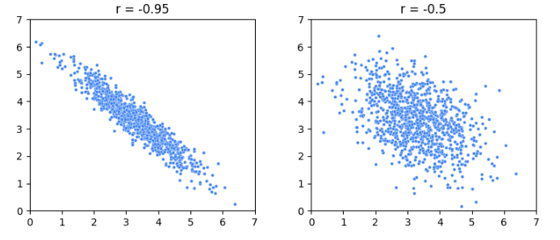

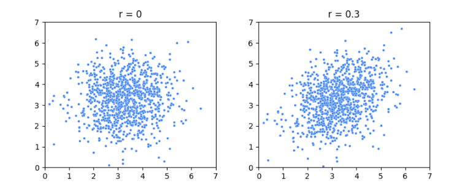

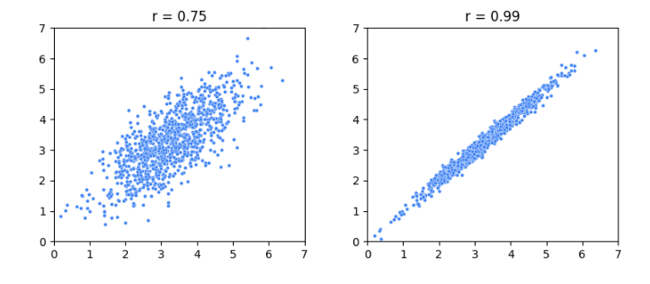

Notice that the closer to -1 or 1 $r$ is, the more linear the data appears. When $r$ is exactly 1 or exactly -1, then the variables are perfectly correlated, and their graph is a line. When $r$ is zero, there is no correlation between the variables, and, in this example, the data appears as a shapeless cloud of points.

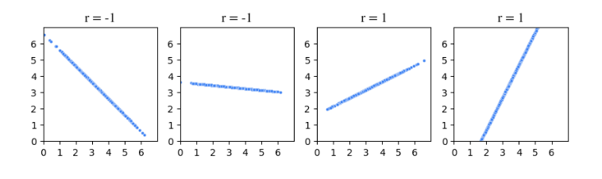

### 8.0.1 Calculate $r$

The formula for $r$ is:

$$r=\frac{covariance(X ,Y)}{(SD X)(SD Y)}$$

where:
$$covariance(X ,Y)=\frac{\sum_{i=1}^n (x_i-\bar{x})(y_i-\bar{y})}{n}$$

Note: The formulas for $r$ and covariance given here represent those used for entire populations. For samples, the denominator of the covariance formula is $n - 1$ and, similarly, the standard deviations in the formula for $r$ are calculated using $n - 1$ instead of $n$. For simplicity, this reading will use the population formulas in its demonstrations.

An easier way of thinking about this calculation is:

the numerator—the covariance—represents the extent to which $X$ and $Y$ vary together from their respective means. When this value is positive, it suggests that high values of $X$ tend to be associated with high values of $Y$, indicating a positive correlation. Conversely, if the value is negative, it suggests that high values of $X$ tend to be associated with low values of $Y$ and vice versa, indicating a negative correlation.

The denominator—the product of the standard deviations—standardizes the units of the numerator. It adjusts for the inherent variability of the individual variables. This makes $r$ a statistic without a unit. It is a pure number, without dimension.

An equivalent way to calculate $r$ is to convert each data point in each variable to standard units (subtract the mean, divide by the standard deviation), then take the average of the products.

Here’s an example. Suppose five students took an exam and you recorded how many hours they spent studying and also their grade. The following table breaks out the calculation of $r$.

remember the formula for standard units:
$$z = \frac{(x - \bar{x})}{SD}$$

[output not shown]

The correlation coefficient is 0.6. Here is a graph of this data:

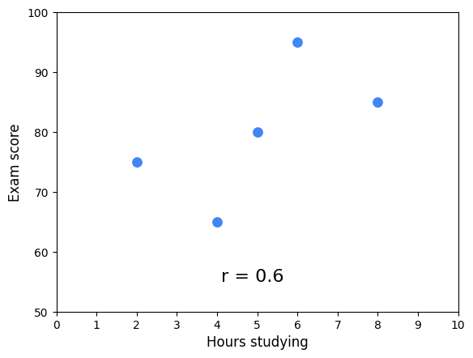

Notice that the cloud of points slopes upwards. This corresponds with $r$ being positive. The correlation coefficient works as an indicator of association because it uses the product of each variable’s deviation from its mean. When the product is positive, it means *both* the $X$ and the $Y$ values are either below their respective means (negative standard units) or above their respective means (positive standard units). They vary together. However, when this product is negative, it means one of the values is above its mean and the other is below it. They vary in opposing directions relative to their respective means.

The following figure illustrates this idea. The figure is divided into quadrants. The vertical line represents the mean $X$ value and the horizontal line represents the mean $Y$ value. Each point is labeled with the product of its standardized scores (refer to the table above). The average of these scores is $r$. When $r$ is positive, more points will tend to be in the positive quadrants, and vice versa.

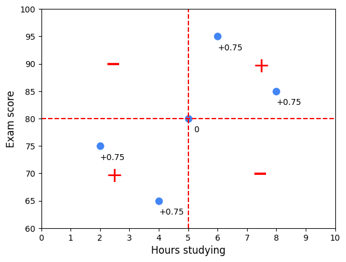

## 8.1 Regression

In the absence of any other information, if you had to guess a randomly selected student’s exam score, the best way for you to minimize your error would be to guess the average of all the students’ scores. But what if you also knew how many hours that student studied? Now, your best guess might be the average score of only the students who studied for that many hours.

Here is an example using a sample of 100 students with study times rounded to the nearest half hour. Suppose you were told a student studied for seven hours. To guess their exam score, one way to minimize error is to guess the average of only the students who studied for seven hours.

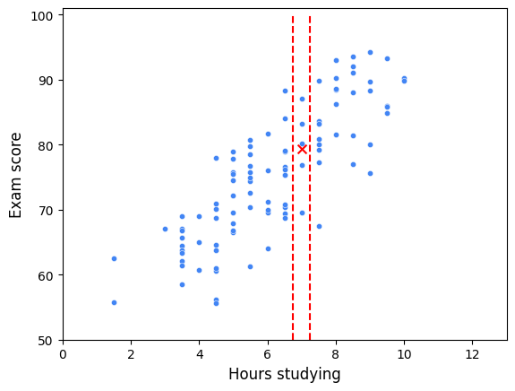

In this scatterplot, all of the students who studied for seven hours fall between the two vertical lines. Their mean exam score is represented by an $X$. Linear regression expands on this concept. A regression line represents the estimated average value of $Y$ for every value of $X$, given the assumptions and limitations of a linear model. In other words, the actual average $Y$ values for each $X$ might not lie exactly on the regression line if the relationship between $X$ and $Y$ is not perfectly linear or if there are other factors influencing $Y$ that are not included in the model. The regression line attempts to balance out these influences to find a straight-line relationship that best fits the data as a whole. It’s an estimation of the central tendency of $Y$, given $X$.

### 8.1.1 The Two Rules to Keep Clear

| **Concept** | **Does it HAVE to lie on the OLS line?** | **Why?** |
| --- | --- | --- |
| **The overall grand mean** $(\bar{X}, \bar{Y})$ | **YES (Always)** | Mathematical constraint of OLS. The line pivots around the single center of gravity of the entire dataset. |
| **Local subgroup means (**$\bar{Y}_{\vert{}X=7}$) | **NO (Rarely)** | These are noisy sample averages. The regression line estimates the *true underlying population trend* by smoothing out these local sample fluctuations into a single straight line. |

### 8.1.2 The regression equation

Now that you know about $r$ and you better understand the concept of regression, you’re ready to put everything together to find the line of best fit through the data. The formula for this line is known as the **regression equation**. There are two keys to this step.

The first is:

- The mean value of $X$ and the mean value of $Y$ (i.e., point (x̄, ȳ)) will always fall on the regression line.

The second is to understand what $r$ means:

For each increase of one standard deviation in $X$, there is an expected increase of $r$ standard deviations in $Y$, on average over $X$.

The following figure illustrates how these concepts work together to determine the regression line.

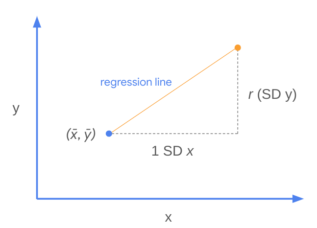

In other words, the slope of the regression line is:
$$m = r \frac{SD Y}{SD X}$$

This is $m$ in the formula for a line: $y = mx + b$. The intercept, represented by $b$, is therefore: $b = y - mx$. Because you know that point ($\bar{x}$, $\bar{y}$) is always on the regression line, you can plug in the $x$ and $y$ values from this point to calculate the intercept. Here’s an example using the original sample of five students.

|  | **Hours studying (X)** | **Exam grade (Y)** |
| --- | --- | --- |
| **mean:** | 5 | 80 |
| **SD:** | 2 | 10 |
| **r:** | **0.6** |  |

Broken into steps:

1. Calculate slope: $m = r \frac{SD Y}{SD X} = 0.6 \frac{10}{2} = 3$.
2. Calculate the intercept: Substitute $\bar{x}$, $\bar{y}$, and $m$ into the equation $y = mx + b$: $80 = 3(5) + b$ → $b = 65$.
3. Generalize to get the regression equation: $y = 3x + 65$.

Here is the regression line overlaid onto the data:

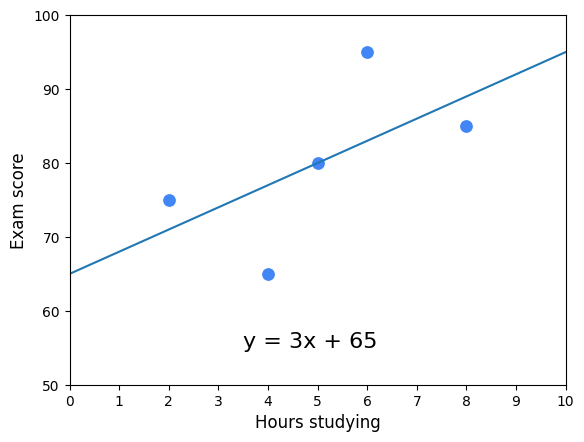

This is referred to as “the regression of $Y$ on $X$.” Here is the regression line for all 100 students:

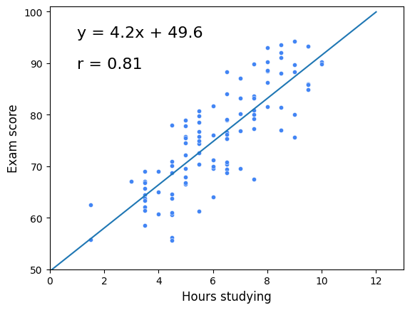

## 8.2 Key Takeaways

Linear regression is one of the most important tools that data professionals use to analyze data. Understanding the fundamental building blocks of simple linear regression will help you as you continue learning about more complex methods of regression analysis. Here are some key points to keep in mind:

- Correlation is a measurement of the way two variables move together.
- $r$ (a.k.a.* Pearson’s correlation coefficient, a.k.a. correlation coefficient) quantifies the strength of the linear relationship between two variables.
  - It always falls in the range of [-1, 1].
  - Variables that tend to vary together from their means are positively correlated. Conversely, variables that tend to vary in opposite ways to their respective means are negatively correlated.
- The regression line estimates the average y value for each $x$ value. It minimizes the error when estimating $y$, given $x$.
- The slope of the regression line is $r \frac{SD Y}{SD X}$.
- The point ($\bar{x}$, $\bar{y}$) is always on the regression line.

# 9 Make linear regression assumptions

Alright, let’s begin with the analyzed stage of the pace framework.

The first task in simple linear regression analysis is checking the assumptions of the model. In addition to the technical needs of the model, you’ll need to consider the business context of the problem you’re working on. This will come in the plan stage. Previously, I spoke about **model assumptions as statements about the data that must be true in order to justify the use of a particular modeling technique**.

Ensuring that we’re using the right model given the data that we have allows us to be confident in the results those models produce. Think of model assumptions as the bridge between the analyze and construct phase of the pace framework. In other words, examine the assumptions before the construct phase when possible. Certain assumptions can only be checked after model construction. Make sure you check those assumptions after you apply the model to confirm if the model is valid or not.

Data visualizations can be used as a tool to determine if model assumptions are met. Thankfully, Python will help you tremendously with generating these, and I’ll be here to guide you through it all too.

There are four key assumptions of a simple linear regression: - linearity, - normality,  - independent observations, - and homoscedasticity.

For now, we’ll focus on understanding what each of these assumptions mean and how they are checked using data visualizations.